# Interpretation and Communication

Mohan Khanal

2025-08-11

# Understanding

This is our first document.

To produce our document:

- we have few commands for texts and R chunks as follows from source pane as you see above. # Heading1 ## Heading2 ### Heading3

Alternatively, we can go to Visual. Begin new line and type / and we get options.

- For R chunks (i.e snippet with R codes) we can press `(grave accent)three times and curley bracket. type small r inside the bracket and close the chunk with`. press ctrl + alt + I(shortcut key). we can also get r chunk from /(backslash) in visual mode.
- For compilation, which we call here Knit we can press knit or press ctrl+ shift + K

# Data Analysis

```r
setwd("D:/DemoPractices/R for Data Science")
rm(list=ls())
gc()
```

## Load Libraries

```r
library(dplyr)
```

```r
library(ggplot2)
library(kableExtra) #please install this before loading, you may not have installed.
library(tidyverse)
```

## Loading Datasets

```r
mtcars <-datasets::mtcars

cardata <- read.csv("D:/DemoPractices/R for Data Science/data/car data.csv")
```

## working with data

A snapshot of first 6 rows of the mtcars:

```r
head(mtcars)
```

```
##                    mpg cyl disp  hp drat    wt  qsec vs am gear carb
## Mazda RX4         21.0   6  160 110 3.90 2.620 16.46  0  1    4    4
## Mazda RX4 Wag     21.0   6  160 110 3.90 2.875 17.02  0  1    4    4
## Datsun 710        22.8   4  108  93 3.85 2.320 18.61  1  1    4    1
## Hornet 4 Drive    21.4   6  258 110 3.08 3.215 19.44  1  0    3    1
## Hornet Sportabout 18.7   8  360 175 3.15 3.440 17.02  0  0    3    2
## Valiant           18.1   6  225 105 2.76 3.460 20.22  1  0    3    1
```

We are exploring car data : variables, variable types. value and value labels.

```r
str(cardata)
```

```
## 'data.frame':    301 obs. of  9 variables:
##  $ Car_Name     : chr  "ritz" "sx4" "ciaz" "wagon r" ...
##  $ Year         : int  2014 2013 2017 2011 2014 2018 2015 2015 2016 2015 ...
##  $ Selling_Price: num  3.35 4.75 7.25 2.85 4.6 9.25 6.75 6.5 8.75 7.45 ...
##  $ Present_Price: num  5.59 9.54 9.85 4.15 6.87 9.83 8.12 8.61 8.89 8.92 ...
##  $ Kms_Driven   : int  27000 43000 6900 5200 42450 2071 18796 33429 20273 42367 ...
##  $ Fuel_Type    : chr  "Petrol" "Diesel" "Petrol" "Petrol" ...
##  $ Seller_Type  : chr  "Dealer" "Dealer" "Dealer" "Dealer" ...
##  $ Transmission : chr  "Manual" "Manual" "Manual" "Manual" ...
##  $ Owner        : int  0 0 0 0 0 0 0 0 0 0 ...
```

```r
#tail()
#glimpse() and other functions.
```

## Descriptive analysis

### Summary Statistics

```r
#summary(cardata)

desc <- cardata %>%
  group_by(Transmission) %>%
  summarize(
    count=n(),
    avg_price = mean(Selling_Price),
    sd_price =sd(Selling_Price),
    max_price=max(Selling_Price))

kableExtra::kable(desc)
```

Table 1 Descriptive Statistics

| Transmission | count | avg_price | sd_price | max_price |
| --- | --- | --- | --- | --- |
| Automatic | 40 | 9.420000 | 8.763243 | 33 |
| Manual | 261 | 3.931992 | 3.777910 | 35 |

### Plots

- Basic plot using plot() function.

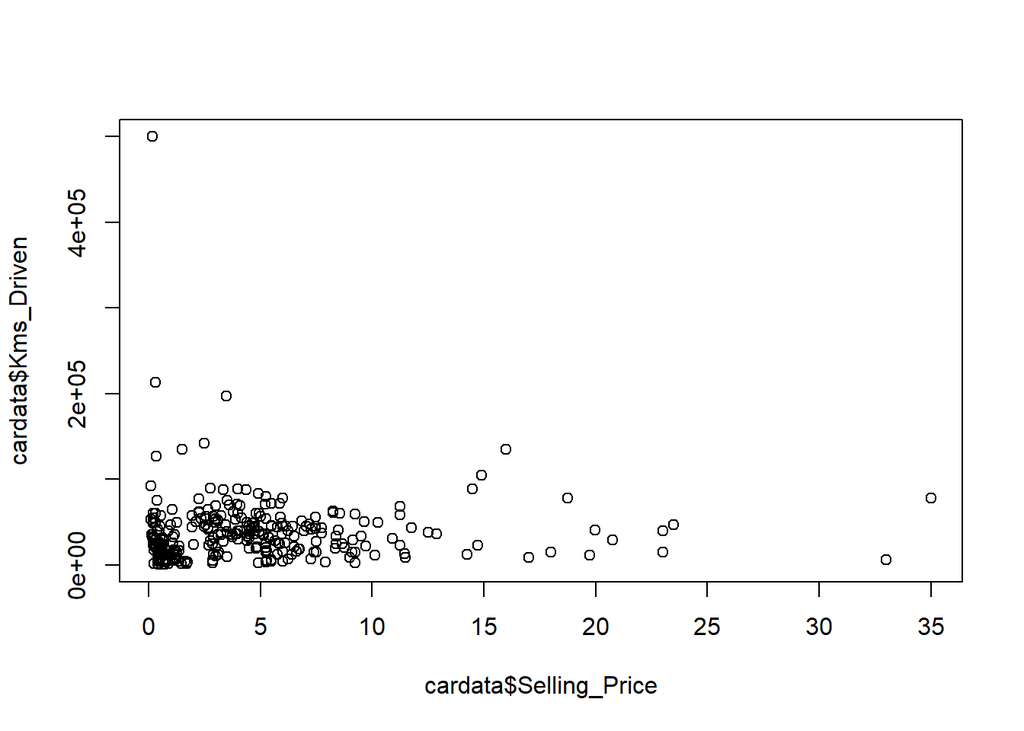

```r
plot(cardata$Selling_Price, cardata$Kms_Driven)
```

- We can also use qplot() function:

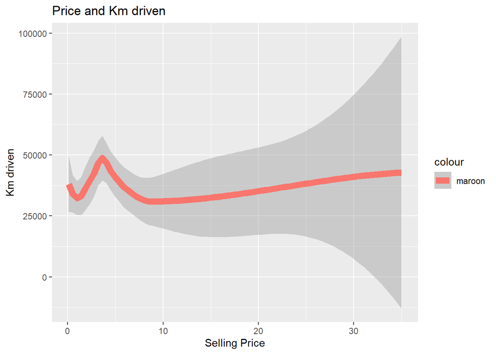

```r
qplot(data=cardata,x= Selling_Price, y= Kms_Driven,
      geom="smooth", color= "maroon",
      size = I(3),
      main ="Price and Km driven",
      xlab="Selling Price",
      ylab = "Km driven")
```

- Using ggplot() functions

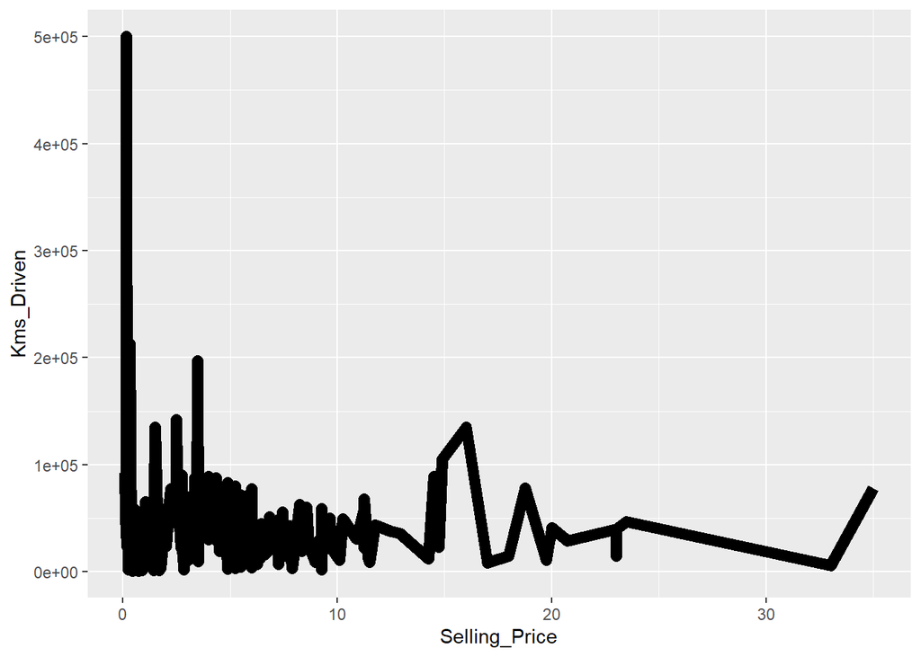

```r
ggplot()+
  geom_line(mapping = aes(x=Selling_Price,y=Kms_Driven),data=cardata)+
    geom_line(
      mapping = aes(x= Selling_Price,y= Kms_Driven),data=cardata,
       colours='maroon',size=3)
```

## Inferential Statistics

- First we Produce cross tabulation results:

```r
# Cross tabulation
crosstab<- modelsummary::datasummary_crosstab(
  Fuel_Type~Transmission,statistic=~N+ Percent("col"),data=cardata)
crosstab
```

| Fuel_Type |  | Automatic | Manual |
| --- | --- | --- | --- |
| CNG | N | 0 | 2 |
|  | % col | 0.0 | 0.8 |
| Diesel | N | 12 | 48 |
|  | % col | 30.0 | 18.4 |
| Petrol | N | 28 | 211 |
|  | % col | 70.0 | 80.8 |

- We can produce Regression results of the mtcars data

```r
regression <- lm(mpg~ hp+wt+am, data =mtcars)
summary(regression)
```

```
##
## Call:
## lm(formula = mpg ~ hp + wt + am, data = mtcars)
##
## Residuals:
##     Min      1Q  Median      3Q     Max
## -3.4221 -1.7924 -0.3788  1.2249  5.5317
##
## Coefficients:
##              Estimate Std. Error t value Pr(>|t|)
## (Intercept) 34.002875   2.642659  12.867 2.82e-13 ***
## hp          -0.037479   0.009605  -3.902 0.000546 ***
## wt          -2.878575   0.904971  -3.181 0.003574 **
## am           2.083710   1.376420   1.514 0.141268
## ---
## Signif. codes:  0 '***' 0.001 '**' 0.01 '*' 0.05 '.' 0.1 ' ' 1
##
## Residual standard error: 2.538 on 28 degrees of freedom
## Multiple R-squared:  0.8399, Adjusted R-squared:  0.8227
## F-statistic: 48.96 on 3 and 28 DF,  p-value: 2.908e-11
```

Thank you.